# Data Preparation

1. Import the dataset

```python
import pandas as pd
import numpy as np

df = pd.read_csv('Customer Service_Requests_from_2010_to_Present.csv', low_memory=False )
df
```

|  | Unique Key | Created Date | Closed Date | Agency | Agency Name | Complaint Type | Descriptor | Location Type | Incident Zip | Incident Address | ... | Bridge Highway Name | Bridge Highway Direction | Road Ramp | Bridge Highway Segment | Garage Lot Name | Ferry Direction | Ferry Terminal Name | Latitude | Longitude | Location |
| --- | --- | --- | --- | --- | --- | --- | --- | --- | --- | --- | --- | --- | --- | --- | --- | --- | --- | --- | --- | --- | --- |
| 0 | 32310363 | 12/31/2015 11:59:45 PM | 01-01-16 0:55 | NYPD | New York City Police Department | Noise - Street/Sidewalk | Loud Music/Party | Street/Sidewalk | 10034.0 | 71 VERMILYEA AVENUE | ... | NaN | NaN | NaN | NaN | NaN | NaN | NaN | 40.865682 | -73.923501 | (40.86568153633767, -73.92350095571744) |
| 1 | 32309934 | 12/31/2015 11:59:44 PM | 01-01-16 1:26 | NYPD | New York City Police Department | Blocked Driveway | No Access | Street/Sidewalk | 11105.0 | 27-07 23 AVENUE | ... | NaN | NaN | NaN | NaN | NaN | NaN | NaN | 40.775945 | -73.915094 | (40.775945312321085, -73.91509393898605) |
| 2 | 32309159 | 12/31/2015 11:59:29 PM | 01-01-16 4:51 | NYPD | New York City Police Department | Blocked Driveway | No Access | Street/Sidewalk | 10458.0 | 2897 VALENTINE AVENUE | ... | NaN | NaN | NaN | NaN | NaN | NaN | NaN | 40.870325 | -73.888525 | (40.870324522111424, -73.88852464418646) |
| 3 | 32305098 | 12/31/2015 11:57:46 PM | 01-01-16 7:43 | NYPD | New York City Police Department | Illegal Parking | Commercial Overnight Parking | Street/Sidewalk | 10461.0 | 2940 BAISLEY AVENUE | ... | NaN | NaN | NaN | NaN | NaN | NaN | NaN | 40.835994 | -73.828379 | (40.83599404683083, -73.82837939584206) |
| 4 | 32306529 | 12/31/2015 11:56:58 PM | 01-01-16 3:24 | NYPD | New York City Police Department | Illegal Parking | Blocked Sidewalk | Street/Sidewalk | 11373.0 | 87-14 57 ROAD | ... | NaN | NaN | NaN | NaN | NaN | NaN | NaN | 40.733060 | -73.874170 | (40.733059618956815, -73.87416975810375) |
| ... | ... | ... | ... | ... | ... | ... | ... | ... | ... | ... | ... | ... | ... | ... | ... | ... | ... | ... | ... | ... | ... |
| 300693 | 30281872 | 03/29/2015 12:33:41 AM | NaN | NYPD | New York City Police Department | Noise - Commercial | Loud Music/Party | Club/Bar/Restaurant | NaN | CRESCENT AVENUE | ... | NaN | NaN | NaN | NaN | NaN | NaN | NaN | NaN | NaN | NaN |
| 300694 | 30281230 | 03/29/2015 12:33:28 AM | 03/29/2015 02:33:59 AM | NYPD | New York City Police Department | Blocked Driveway | Partial Access | Street/Sidewalk | 11418.0 | 100-17 87 AVENUE | ... | NaN | NaN | NaN | NaN | NaN | NaN | NaN | 40.694077 | -73.846087 | (40.69407728322387, -73.8460866160573) |
| 300695 | 30283424 | 03/29/2015 12:33:03 AM | 03/29/2015 03:40:20 AM | NYPD | New York City Police Department | Noise - Commercial | Loud Music/Party | Club/Bar/Restaurant | 11206.0 | 162 THROOP AVENUE | ... | NaN | NaN | NaN | NaN | NaN | NaN | NaN | 40.699590 | -73.944234 | (40.69959035300927, -73.94423377144169) |
| 300696 | 30280004 | 03/29/2015 12:33:02 AM | 03/29/2015 04:38:35 AM | NYPD | New York City Police Department | Noise - Commercial | Loud Music/Party | Club/Bar/Restaurant | 10461.0 | 3151 EAST TREMONT AVENUE | ... | NaN | NaN | NaN | NaN | NaN | NaN | NaN | 40.837708 | -73.834587 | (40.8377075854206, -73.83458731019586) |
| 300697 | 30281825 | 03/29/2015 12:33:01 AM | 03/29/2015 04:41:50 AM | NYPD | New York City Police Department | Noise - Commercial | Loud Music/Party | Store/Commercial | 10036.0 | 251 WEST 48 STREET | ... | NaN | NaN | NaN | NaN | NaN | NaN | NaN | 40.760583 | -73.985922 | (40.76058322950115, -73.98592204392392) |

300698 rows × 53 columns

```python
df.info()
```

```
<class 'pandas.core.frame.DataFrame'>
RangeIndex: 300698 entries, 0 to 300697
Data columns (total 53 columns):
 #   Column                          Non-Null Count   Dtype
---  ------                          --------------   -----
 0   Unique Key                      300698 non-null  int64
 1   Created Date                    300698 non-null  object
 2   Closed Date                     298534 non-null  object
 3   Agency                          300698 non-null  object
 4   Agency Name                     300698 non-null  object
 5   Complaint Type                  300698 non-null  object
 6   Descriptor                      294784 non-null  object
 7   Location Type                   300567 non-null  object
 8   Incident Zip                    298083 non-null  float64
 9   Incident Address                256288 non-null  object
```

[output cut: 45 more lines]

```python
df.describe()
```

|  | Unique Key | Incident Zip | X Coordinate (State Plane) | Y Coordinate (State Plane) | School or Citywide Complaint | Vehicle Type | Taxi Company Borough | Taxi Pick Up Location | Garage Lot Name | Latitude | Longitude |
| --- | --- | --- | --- | --- | --- | --- | --- | --- | --- | --- | --- |
| count | 3.006980e+05 | 298083.000000 | 2.971580e+05 | 297158.000000 | 0.0 | 0.0 | 0.0 | 0.0 | 0.0 | 297158.000000 | 297158.000000 |
| mean | 3.130054e+07 | 10848.888645 | 1.004854e+06 | 203754.534416 | NaN | NaN | NaN | NaN | NaN | 40.725885 | -73.925630 |
| std | 5.738547e+05 | 583.182081 | 2.175338e+04 | 29880.183529 | NaN | NaN | NaN | NaN | NaN | 0.082012 | 0.078454 |
| min | 3.027948e+07 | 83.000000 | 9.133570e+05 | 121219.000000 | NaN | NaN | NaN | NaN | NaN | 40.499135 | -74.254937 |
| 25% | 3.080118e+07 | 10310.000000 | 9.919752e+05 | 183343.000000 | NaN | NaN | NaN | NaN | NaN | 40.669796 | -73.972142 |
| 50% | 3.130436e+07 | 11208.000000 | 1.003158e+06 | 201110.500000 | NaN | NaN | NaN | NaN | NaN | 40.718661 | -73.931781 |
| 75% | 3.178446e+07 | 11238.000000 | 1.018372e+06 | 224125.250000 | NaN | NaN | NaN | NaN | NaN | 40.781840 | -73.876805 |
| max | 3.231065e+07 | 11697.000000 | 1.067173e+06 | 271876.000000 | NaN | NaN | NaN | NaN | NaN | 40.912869 | -73.700760 |

2. Convert the columns "Created Date" and "Closed Date" to datetime

datatype and create a new column "Request_Closing_Time" as the time elapsed between request creation and request closing

```python
df.dtypes
```

```
Unique Key                          int64
Created Date                       object
Closed Date                        object
Agency                             object
Agency Name                        object
Complaint Type                     object
Descriptor                         object
Location Type                      object
Incident Zip                      float64
Incident Address                   object
Street Name                        object
Cross Street 1                     object
Cross Street 2                     object
Intersection Street 1              object
Intersection Street 2              object
Address Type                       object
City                               object
Landmark                           object
Facility Type                      object
Status                             object
Due Date                           object
Resolution Description             object
Resolution Action Updated Date     object
Community Board                    object
Borough                            object
X Coordinate (State Plane)        float64
Y Coordinate (State Plane)        float64
Park Facility Name                 object
Park Borough                       object
School Name                        object
School Number                      object
School Region                      object
School Code                        object
School Phone Number                object
School Address                     object
School City                        object
School State                       object
School Zip                         object
School Not Found                   object
School or Citywide Complaint      float64
Vehicle Type                      float64
Taxi Company Borough              float64
Taxi Pick Up Location             float64
Bridge Highway Name                object
Bridge Highway Direction           object
Road Ramp                          object
Bridge Highway Segment             object
Garage Lot Name                   float64
Ferry Direction                    object
Ferry Terminal Name                object
Latitude                          float64
Longitude                         float64
Location                           object
dtype: object
```

2. Convert the columns "Created Date" and "Closed Date" to datetime datatype and create a new column "Request_Closing_Time" as the time elapsed between request creation and request closing

```python
# Convert to datetime
df['Created Date'] = pd.to_datetime(df['Created Date'], format='mixed')
df['Closed Date'] = pd.to_datetime(df['Closed Date'], format='mixed')

# Calculate request closing time
df['Request_Closing_Time'] = df['Closed Date'] - df['Created Date']
print(df[['Created Date', 'Closed Date', 'Request_Closing_Time']].dtypes)
```

```
Created Date             datetime64[ns]
Closed Date              datetime64[ns]
Request_Closing_Time    timedelta64[ns]
dtype: object
```

```python
df.dtypes
```

```
Unique Key                                  int64
Created Date                       datetime64[ns]
Closed Date                        datetime64[ns]
Agency                                     object
Agency Name                                object
Complaint Type                             object
Descriptor                                 object
Location Type                              object
Incident Zip                              float64
Incident Address                           object
Street Name                                object
Cross Street 1                             object
Cross Street 2                             object
Intersection Street 1                      object
Intersection Street 2                      object
Address Type                               object
City                                       object
Landmark                                   object
Facility Type                              object
Status                                     object
Due Date                                   object
Resolution Description                     object
Resolution Action Updated Date             object
Community Board                            object
Borough                                    object
X Coordinate (State Plane)                float64
Y Coordinate (State Plane)                float64
Park Facility Name                         object
Park Borough                               object
School Name                                object
School Number                              object
School Region                              object
School Code                                object
School Phone Number                        object
School Address                             object
School City                                object
School State                               object
School Zip                                 object
School Not Found                           object
School or Citywide Complaint              float64
Vehicle Type                              float64
Taxi Company Borough                      float64
Taxi Pick Up Location                     float64
Bridge Highway Name                        object
Bridge Highway Direction                   object
Road Ramp                                  object
Bridge Highway Segment                     object
Garage Lot Name                           float64
Ferry Direction                            object
Ferry Terminal Name                        object
Latitude                                  float64
Longitude                                 float64
Location                                   object
Request_Closing_Time              timedelta64[ns]
dtype: object
```

```
3. Write a python program to drop irrelevant Columns which are listed
```

```python
df.head()
```

|  | Unique Key | Created Date | Closed Date | Agency | Agency Name | Complaint Type | Descriptor | Location Type | Incident Zip | Incident Address | ... | Bridge Highway Direction | Road Ramp | Bridge Highway Segment | Garage Lot Name | Ferry Direction | Ferry Terminal Name | Latitude | Longitude | Location | Request_Closing_Time |
| --- | --- | --- | --- | --- | --- | --- | --- | --- | --- | --- | --- | --- | --- | --- | --- | --- | --- | --- | --- | --- | --- |
| 0 | 32310363 | 2015-12-31 23:59:45 | 2016-01-01 00:55:00 | NYPD | New York City Police Department | Noise - Street/Sidewalk | Loud Music/Party | Street/Sidewalk | 10034.0 | 71 VERMILYEA AVENUE | ... | NaN | NaN | NaN | NaN | NaN | NaN | 40.865682 | -73.923501 | (40.86568153633767, -73.92350095571744) | 0 days 00:55:15 |
| 1 | 32309934 | 2015-12-31 23:59:44 | 2016-01-01 01:26:00 | NYPD | New York City Police Department | Blocked Driveway | No Access | Street/Sidewalk | 11105.0 | 27-07 23 AVENUE | ... | NaN | NaN | NaN | NaN | NaN | NaN | 40.775945 | -73.915094 | (40.775945312321085, -73.91509393898605) | 0 days 01:26:16 |
| 2 | 32309159 | 2015-12-31 23:59:29 | 2016-01-01 04:51:00 | NYPD | New York City Police Department | Blocked Driveway | No Access | Street/Sidewalk | 10458.0 | 2897 VALENTINE AVENUE | ... | NaN | NaN | NaN | NaN | NaN | NaN | 40.870325 | -73.888525 | (40.870324522111424, -73.88852464418646) | 0 days 04:51:31 |
| 3 | 32305098 | 2015-12-31 23:57:46 | 2016-01-01 07:43:00 | NYPD | New York City Police Department | Illegal Parking | Commercial Overnight Parking | Street/Sidewalk | 10461.0 | 2940 BAISLEY AVENUE | ... | NaN | NaN | NaN | NaN | NaN | NaN | 40.835994 | -73.828379 | (40.83599404683083, -73.82837939584206) | 0 days 07:45:14 |
| 4 | 32306529 | 2015-12-31 23:56:58 | 2016-01-01 03:24:00 | NYPD | New York City Police Department | Illegal Parking | Blocked Sidewalk | Street/Sidewalk | 11373.0 | 87-14 57 ROAD | ... | NaN | NaN | NaN | NaN | NaN | NaN | 40.733060 | -73.874170 | (40.733059618956815, -73.87416975810375) | 0 days 03:27:02 |

5 rows × 54 columns

```python
# List of irrelevant columns to drop
irrelevant= [
    'Agency Name', 'Incident Address', 'Street Name', 'Cross Street 1', 'Cross Street 2',
    'Intersection Street 1', 'Intersection Street 2', 'Address Type', 'Park Facility Name',
    'Park Borough', 'School Name', 'School Number', 'School Region', 'School Code',
    'School Phone Number', 'School Address', 'School City', 'School State', 'School Zip',
    'School Not Found', 'School or Citywide Complaint', 'Vehicle Type', 'Taxi Company Borough',
    'Taxi Pick Up Location', 'Bridge Highway Name', 'Bridge Highway Direction', 'Road Ramp',
    'Bridge Highway Segment', 'Garage Lot Name', 'Ferry Direction', 'Ferry Terminal Name',
    'Landmark', 'X Coordinate (State Plane)', 'Y Coordinate (State Plane)', 'Due Date',
    'Resolution Action Updated Date', 'Community Board', 'Facility Type', 'Location'
]

# Drop the columns (ignore any not found in case the dataset varies slightly)
df = df.drop(columns=[col for col in irrelevant if col in df.columns])

df
```

|  | Unique Key | Created Date | Closed Date | Agency | Complaint Type | Descriptor | Location Type | Incident Zip | City | Status | Resolution Description | Borough | Latitude | Longitude | Request_Closing_Time |
| --- | --- | --- | --- | --- | --- | --- | --- | --- | --- | --- | --- | --- | --- | --- | --- |
| 0 | 32310363 | 2015-12-31 23:59:45 | 2016-01-01 00:55:00 | NYPD | Noise - Street/Sidewalk | Loud Music/Party | Street/Sidewalk | 10034.0 | NEW YORK | Closed | The Police Department responded and upon arriv... | MANHATTAN | 40.865682 | -73.923501 | 0 days 00:55:15 |
| 1 | 32309934 | 2015-12-31 23:59:44 | 2016-01-01 01:26:00 | NYPD | Blocked Driveway | No Access | Street/Sidewalk | 11105.0 | ASTORIA | Closed | The Police Department responded to the complai... | QUEENS | 40.775945 | -73.915094 | 0 days 01:26:16 |
| 2 | 32309159 | 2015-12-31 23:59:29 | 2016-01-01 04:51:00 | NYPD | Blocked Driveway | No Access | Street/Sidewalk | 10458.0 | BRONX | Closed | The Police Department responded and upon arriv... | BRONX | 40.870325 | -73.888525 | 0 days 04:51:31 |
| 3 | 32305098 | 2015-12-31 23:57:46 | 2016-01-01 07:43:00 | NYPD | Illegal Parking | Commercial Overnight Parking | Street/Sidewalk | 10461.0 | BRONX | Closed | The Police Department responded to the complai... | BRONX | 40.835994 | -73.828379 | 0 days 07:45:14 |
| 4 | 32306529 | 2015-12-31 23:56:58 | 2016-01-01 03:24:00 | NYPD | Illegal Parking | Blocked Sidewalk | Street/Sidewalk | 11373.0 | ELMHURST | Closed | The Police Department responded and upon arriv... | QUEENS | 40.733060 | -73.874170 | 0 days 03:27:02 |
| ... | ... | ... | ... | ... | ... | ... | ... | ... | ... | ... | ... | ... | ... | ... | ... |
| 300693 | 30281872 | 2015-03-29 00:33:41 | NaT | NYPD | Noise - Commercial | Loud Music/Party | Club/Bar/Restaurant | NaN | NaN | Open | Your complaint has been forwarded to the New Y... | Unspecified | NaN | NaN | NaT |
| 300694 | 30281230 | 2015-03-29 00:33:28 | 2015-03-29 02:33:59 | NYPD | Blocked Driveway | Partial Access | Street/Sidewalk | 11418.0 | RICHMOND HILL | Closed | The Police Department responded and upon arriv... | QUEENS | 40.694077 | -73.846087 | 0 days 02:00:31 |
| 300695 | 30283424 | 2015-03-29 00:33:03 | 2015-03-29 03:40:20 | NYPD | Noise - Commercial | Loud Music/Party | Club/Bar/Restaurant | 11206.0 | BROOKLYN | Closed | The Police Department responded to the complai... | BROOKLYN | 40.699590 | -73.944234 | 0 days 03:07:17 |
| 300696 | 30280004 | 2015-03-29 00:33:02 | 2015-03-29 04:38:35 | NYPD | Noise - Commercial | Loud Music/Party | Club/Bar/Restaurant | 10461.0 | BRONX | Closed | The Police Department responded to the complai... | BRONX | 40.837708 | -73.834587 | 0 days 04:05:33 |
| 300697 | 30281825 | 2015-03-29 00:33:01 | 2015-03-29 04:41:50 | NYPD | Noise - Commercial | Loud Music/Party | Store/Commercial | 10036.0 | NEW YORK | Closed | The Police Department responded to the complai... | MANHATTAN | 40.760583 | -73.985922 | 0 days 04:08:49 |

300698 rows × 15 columns

```python
df.head()
```

|  | Unique Key | Created Date | Closed Date | Agency | Complaint Type | Descriptor | Location Type | Incident Zip | City | Status | Resolution Description | Borough | Latitude | Longitude | Request_Closing_Time |
| --- | --- | --- | --- | --- | --- | --- | --- | --- | --- | --- | --- | --- | --- | --- | --- |
| 0 | 32310363 | 2015-12-31 23:59:45 | 2016-01-01 00:55:00 | NYPD | Noise - Street/Sidewalk | Loud Music/Party | Street/Sidewalk | 10034.0 | NEW YORK | Closed | The Police Department responded and upon arriv... | MANHATTAN | 40.865682 | -73.923501 | 0 days 00:55:15 |
| 1 | 32309934 | 2015-12-31 23:59:44 | 2016-01-01 01:26:00 | NYPD | Blocked Driveway | No Access | Street/Sidewalk | 11105.0 | ASTORIA | Closed | The Police Department responded to the complai... | QUEENS | 40.775945 | -73.915094 | 0 days 01:26:16 |
| 2 | 32309159 | 2015-12-31 23:59:29 | 2016-01-01 04:51:00 | NYPD | Blocked Driveway | No Access | Street/Sidewalk | 10458.0 | BRONX | Closed | The Police Department responded and upon arriv... | BRONX | 40.870325 | -73.888525 | 0 days 04:51:31 |
| 3 | 32305098 | 2015-12-31 23:57:46 | 2016-01-01 07:43:00 | NYPD | Illegal Parking | Commercial Overnight Parking | Street/Sidewalk | 10461.0 | BRONX | Closed | The Police Department responded to the complai... | BRONX | 40.835994 | -73.828379 | 0 days 07:45:14 |
| 4 | 32306529 | 2015-12-31 23:56:58 | 2016-01-01 03:24:00 | NYPD | Illegal Parking | Blocked Sidewalk | Street/Sidewalk | 11373.0 | ELMHURST | Closed | The Police Department responded and upon arriv... | QUEENS | 40.733060 | -73.874170 | 0 days 03:27:02 |

4. Write a python program to remove the NaN missing values from updated dataframe.

```python
df.isna().sum()
```

```
Unique Key                   0
Created Date                 0
Closed Date               2164
Agency                       0
Complaint Type               0
Descriptor                5914
Location Type              131
Incident Zip              2615
City                      2614
Status                       0
Resolution Description       0
Borough                      0
Latitude                  3540
Longitude                 3540
Request_Closing_Time      2164
dtype: int64
```

```python
df.dropna(inplace=True)
df
```

|  | Unique Key | Created Date | Closed Date | Agency | Complaint Type | Descriptor | Location Type | Incident Zip | City | Status | Resolution Description | Borough | Latitude | Longitude | Request_Closing_Time |
| --- | --- | --- | --- | --- | --- | --- | --- | --- | --- | --- | --- | --- | --- | --- | --- |
| 0 | 32310363 | 2015-12-31 23:59:45 | 2016-01-01 00:55:00 | NYPD | Noise - Street/Sidewalk | Loud Music/Party | Street/Sidewalk | 10034.0 | NEW YORK | Closed | The Police Department responded and upon arriv... | MANHATTAN | 40.865682 | -73.923501 | 0 days 00:55:15 |
| 1 | 32309934 | 2015-12-31 23:59:44 | 2016-01-01 01:26:00 | NYPD | Blocked Driveway | No Access | Street/Sidewalk | 11105.0 | ASTORIA | Closed | The Police Department responded to the complai... | QUEENS | 40.775945 | -73.915094 | 0 days 01:26:16 |
| 2 | 32309159 | 2015-12-31 23:59:29 | 2016-01-01 04:51:00 | NYPD | Blocked Driveway | No Access | Street/Sidewalk | 10458.0 | BRONX | Closed | The Police Department responded and upon arriv... | BRONX | 40.870325 | -73.888525 | 0 days 04:51:31 |
| 3 | 32305098 | 2015-12-31 23:57:46 | 2016-01-01 07:43:00 | NYPD | Illegal Parking | Commercial Overnight Parking | Street/Sidewalk | 10461.0 | BRONX | Closed | The Police Department responded to the complai... | BRONX | 40.835994 | -73.828379 | 0 days 07:45:14 |
| 4 | 32306529 | 2015-12-31 23:56:58 | 2016-01-01 03:24:00 | NYPD | Illegal Parking | Blocked Sidewalk | Street/Sidewalk | 11373.0 | ELMHURST | Closed | The Police Department responded and upon arriv... | QUEENS | 40.733060 | -73.874170 | 0 days 03:27:02 |
| ... | ... | ... | ... | ... | ... | ... | ... | ... | ... | ... | ... | ... | ... | ... | ... |
| 300692 | 30281370 | 2015-03-29 00:34:32 | 2015-03-29 01:13:01 | NYPD | Noise - Commercial | Loud Music/Party | Store/Commercial | 10002.0 | NEW YORK | Closed | The Police Department responded to the complai... | MANHATTAN | 40.716053 | -73.991378 | 0 days 00:38:29 |
| 300694 | 30281230 | 2015-03-29 00:33:28 | 2015-03-29 02:33:59 | NYPD | Blocked Driveway | Partial Access | Street/Sidewalk | 11418.0 | RICHMOND HILL | Closed | The Police Department responded and upon arriv... | QUEENS | 40.694077 | -73.846087 | 0 days 02:00:31 |
| 300695 | 30283424 | 2015-03-29 00:33:03 | 2015-03-29 03:40:20 | NYPD | Noise - Commercial | Loud Music/Party | Club/Bar/Restaurant | 11206.0 | BROOKLYN | Closed | The Police Department responded to the complai... | BROOKLYN | 40.699590 | -73.944234 | 0 days 03:07:17 |
| 300696 | 30280004 | 2015-03-29 00:33:02 | 2015-03-29 04:38:35 | NYPD | Noise - Commercial | Loud Music/Party | Club/Bar/Restaurant | 10461.0 | BRONX | Closed | The Police Department responded to the complai... | BRONX | 40.837708 | -73.834587 | 0 days 04:05:33 |
| 300697 | 30281825 | 2015-03-29 00:33:01 | 2015-03-29 04:41:50 | NYPD | Noise - Commercial | Loud Music/Party | Store/Commercial | 10036.0 | NEW YORK | Closed | The Police Department responded to the complai... | MANHATTAN | 40.760583 | -73.985922 | 0 days 04:08:49 |

291107 rows × 15 columns

```python
df.isna().sum()
```

```
Unique Key                0
Created Date              0
Closed Date               0
Agency                    0
Complaint Type            0
Descriptor                0
Location Type             0
Incident Zip              0
City                      0
Status                    0
Resolution Description    0
Borough                   0
Latitude                  0
Longitude                 0
Request_Closing_Time      0
dtype: int64
```

5. Write a python program to see the unique values from all the columns in the dataframe.

```python
for column in df.columns:
    unique_vals = df[column].unique()
    print(f"Total Unique Values: {len(unique_vals)}")
    print(f"Example Unique Values: {unique_vals[:4]}\n")
```

```
Total Unique Values: 291107
Example Unique Values: [32310363 32309934 32309159 32305098]

Total Unique Values: 251970
Example Unique Values: <DatetimeArray>
['2015-12-31 23:59:45', '2015-12-31 23:59:44', '2015-12-31 23:59:29',
 '2015-12-31 23:57:46']
Length: 4, dtype: datetime64[ns]

Total Unique Values: 231991
Example Unique Values: <DatetimeArray>
['2016-01-01 00:55:00', '2016-01-01 01:26:00', '2016-01-01 04:51:00',
 '2016-01-01 07:43:00']
Length: 4, dtype: datetime64[ns]

Total Unique Values: 1
Example Unique Values: ['NYPD']

Total Unique Values: 15
Example Unique Values: ['Noise - Street/Sidewalk' 'Blocked Driveway' 'Illegal Parking'
 'Derelict Vehicle']

Total Unique Values: 41
Example Unique Values: ['Loud Music/Party' 'No Access' 'Commercial Overnight Parking'
 'Blocked Sidewalk']

Total Unique Values: 14
Example Unique Values: ['Street/Sidewalk' 'Club/Bar/Restaurant' 'Store/Commercial'
 'House of Worship']

Total Unique Values: 200
Example Unique Values: [10034. 11105. 10458. 10461.]

Total Unique Values: 53
Example Unique Values: ['NEW YORK' 'ASTORIA' 'BRONX' 'ELMHURST']

Total Unique Values: 1
Example Unique Values: ['Closed']

Total Unique Values: 12
Example Unique Values: ['The Police Department responded and upon arrival those responsible for the condition were gone.'
 'The Police Department responded to the complaint and with the information available observed no evidence of the violation at that time.'
 'The Police Department responded to the complaint and took action to fix the condition.'
 'The Police Department issued a summons in response to the complaint.']

Total Unique Values: 5
Example Unique Values: ['MANHATTAN' 'QUEENS' 'BRONX' 'BROOKLYN']

Total Unique Values: 123013
Example Unique Values: [40.86568154 40.77594531 40.87032452 40.83599405]

Total Unique Values: 123112
Example Unique Values: [-73.92350096 -73.91509394 -73.88852464 -73.8283794 ]

Total Unique Values: 47134
Example Unique Values: <TimedeltaArray>
['0 days 00:55:15', '0 days 01:26:16', '0 days 04:51:31', '0 days 07:45:14']
Length: 4, dtype: timedelta64[ns]
```

```python
df.info()
```

```
<class 'pandas.core.frame.DataFrame'>
Index: 291107 entries, 0 to 300697
Data columns (total 15 columns):
 #   Column                  Non-Null Count   Dtype
---  ------                  --------------   -----
 0   Unique Key              291107 non-null  int64
 1   Created Date            291107 non-null  datetime64[ns]
 2   Closed Date             291107 non-null  datetime64[ns]
 3   Agency                  291107 non-null  object
 4   Complaint Type          291107 non-null  object
 5   Descriptor              291107 non-null  object
 6   Location Type           291107 non-null  object
 7   Incident Zip            291107 non-null  float64
 8   City                    291107 non-null  object
 9   Status                  291107 non-null  object
 10  Resolution Description  291107 non-null  object
 11  Borough                 291107 non-null  object
 12  Latitude                291107 non-null  float64
 13  Longitude               291107 non-null  float64
 14  Request_Closing_Time    291107 non-null  timedelta64[ns]
dtypes: datetime64[ns](2), float64(3), int64(1), object(8), timedelta64[ns](1)
memory usage: 35.5+ MB
```

# Data Analysis

1. Write a Python program to show summary statistics of sum, mean, standard deviation, skewness, and kurtosis of the data frame.

```python
# Show stats only for numerical columns
print("          Statistics Summery      ")
print("--------------------------------------")
print("Sum:\n", df.sum(numeric_only=True))
print("--------------------------------------")
print("mean:\n", df.mean(numeric_only=True))
print("--------------------------------------")
print("Standard deviation:\n", df.std(numeric_only=True))
print("--------------------------------------")
print("Skewness:\n", df.skew(numeric_only=True))
print("--------------------------------------")
print("Kurtosis:\n", df.kurt(numeric_only=True))
print("--------------------------------------")
```

```
          Statistics Summery
--------------------------------------
Sum:
 Unique Key      9.112108e+12
Incident Zip    3.160833e+09
Latitude        1.185553e+07
Longitude      -2.152010e+07
dtype: float64
--------------------------------------
mean:
 Unique Key      3.130158e+07
Incident Zip    1.085798e+04
Latitude        4.072568e+01
Longitude      -7.392504e+01
dtype: float64
--------------------------------------
Standard deviation:
 Unique Key      575377.738707
Incident Zip       580.280774
Latitude             0.082411
Longitude            0.078654
dtype: float64
--------------------------------------
Skewness:
 Unique Key      0.016898
Incident Zip   -2.553956
Latitude        0.123114
Longitude      -0.312739
dtype: float64
--------------------------------------
Kurtosis:
 Unique Key      -1.176593
Incident Zip    37.827777
Latitude        -0.734818
Longitude        1.455600
dtype: float64
--------------------------------------
```

2. Write a Python program to calculate and show correlation of all variables.

```python
print(df.corr(numeric_only=True))
```

```
              Unique Key  Incident Zip  Latitude  Longitude
Unique Key      1.000000      0.025492 -0.032613  -0.008621
Incident Zip    0.025492      1.000000 -0.499081   0.385934
Latitude       -0.032613     -0.499081  1.000000   0.368819
Longitude      -0.008621      0.385934  0.368819   1.000000
```

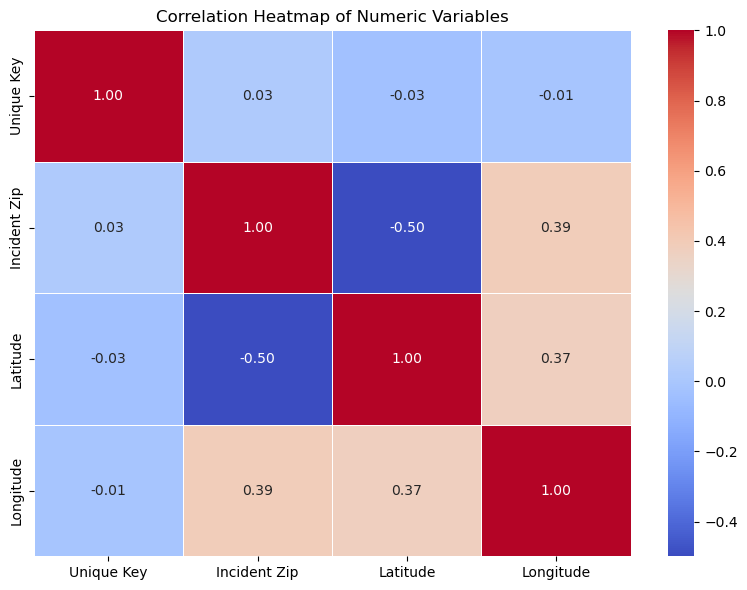

```python
import matplotlib.pyplot as plt
import seaborn as sns

# Compute correlation matrix
corr_matrix = df.corr(numeric_only=True)

# Plot heatmap
plt.figure(figsize=(8, 6))
sns.heatmap(corr_matrix, annot=True, fmt='.2f', cmap='coolwarm', linewidths=0.5)

plt.title('Correlation Heatmap of Numeric Variables')
plt.tight_layout()
plt.show()
```

# Data Exploration

1.Provide four major insights through visualization that you come up after data mining.

1.1 Insight one

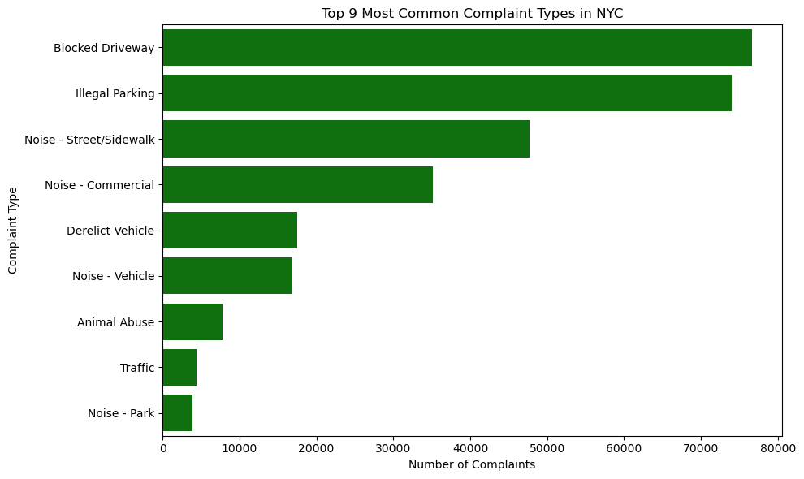

```python
import matplotlib.pyplot as plt
import seaborn as sns
top_complaints = df['Complaint Type'].value_counts().nlargest(9).reset_index()
top_complaints.columns = ['Complaint Type', 'Count']

# Plot
plt.figure(figsize=(10, 6))
sns.barplot(data=top_complaints, x='Count', y='Complaint Type', color='green')
plt.title('Top 9 Most Common Complaint Types in NYC')
plt.xlabel('Number of Complaints')
plt.ylabel('Complaint Type')
plt.tight_layout()
plt.show()
```

1.2 Insight 2

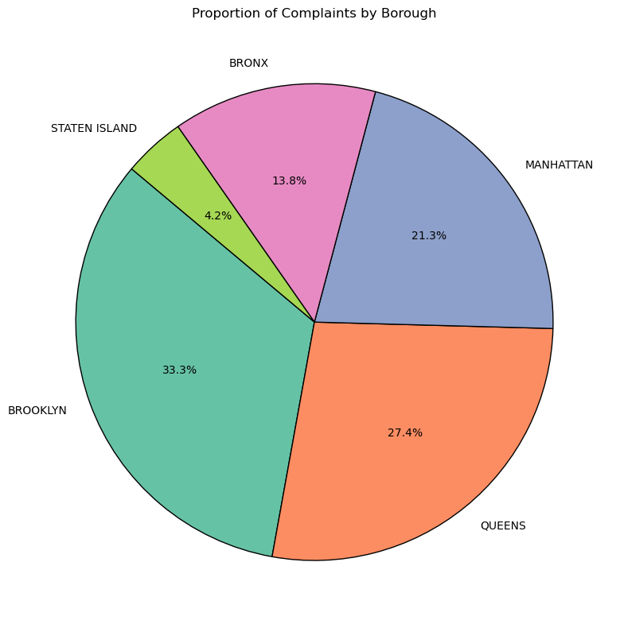

```python
# Count of complaints per borough
borough_counts = df['Borough'].value_counts()

# Plot pie chart
plt.figure(figsize=(8, 8))
plt.pie(borough_counts.values,
        labels=borough_counts.index,
        autopct='%1.1f%%',
        startangle=140,
        colors=sns.color_palette('Set2'),
        wedgeprops={'edgecolor': 'black'})

plt.title('Proportion of Complaints by Borough')
plt.tight_layout()
plt.show()
```

1.3 Insight three

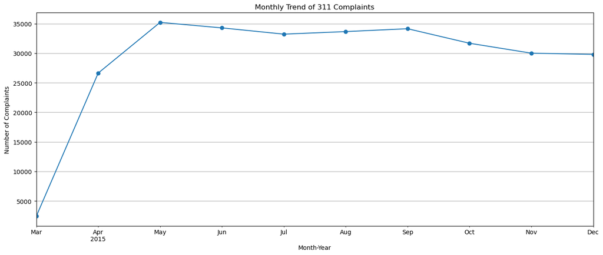

```python
# Ensure datetime format
df['Created Date'] = pd.to_datetime(df['Created Date'], errors='coerce')

# Extract month and year
df['Month_Year'] = df['Created Date'].dt.to_period('M')

monthly_trend = df['Month_Year'].value_counts().sort_index()

plt.figure(figsize=(14, 6))
monthly_trend.plot(kind='line', marker='o')
plt.title('Monthly Trend of 311 Complaints')
plt.xlabel('Month-Year')
plt.ylabel('Number of Complaints')
plt.xticks(rotation=45)
plt.grid(True)
plt.tight_layout()
plt.show()
```

1.4 Insight Four

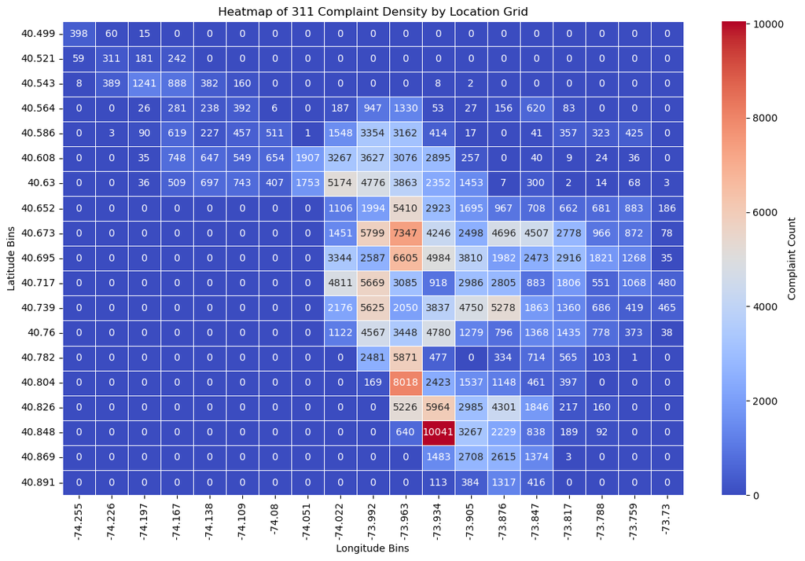

```python
# Drop missing location data
geo_df = df.dropna(subset=['Latitude', 'Longitude'])

# Bin the latitude and longitude into a grid
lat_bins = np.linspace(geo_df['Latitude'].min(), geo_df['Latitude'].max(), 20)
lon_bins = np.linspace(geo_df['Longitude'].min(), geo_df['Longitude'].max(), 20)

# Create 2D histogram of counts
heatmap_data, x_edges, y_edges = np.histogram2d(
    geo_df['Latitude'],
    geo_df['Longitude'],
    bins=[lat_bins, lon_bins]
)

# Create a DataFrame for seaborn heatmap
heatmap_df = pd.DataFrame(
    heatmap_data,
    index=[f"{round(b, 3)}" for b in lat_bins[:-1]],
    columns=[f"{round(b, 3)}" for b in lon_bins[:-1]]
)

# Plot as a heatmap similar to correlation matrix
plt.figure(figsize=(12, 8))
sns.heatmap(
    heatmap_df,
    cmap='coolwarm',
    annot=True,
    fmt=".0f",
    linewidths=0.5,
    cbar_kws={'label': 'Complaint Count'}
)

plt.title("Heatmap of 311 Complaint Density by Location Grid")
plt.xlabel("Longitude Bins")
plt.ylabel("Latitude Bins")
plt.tight_layout()
plt.show()
```

2. Arrange the complaint types according to their average 'Request_Closing_Time', categorized by various locations. Illustrate it through graph as well.

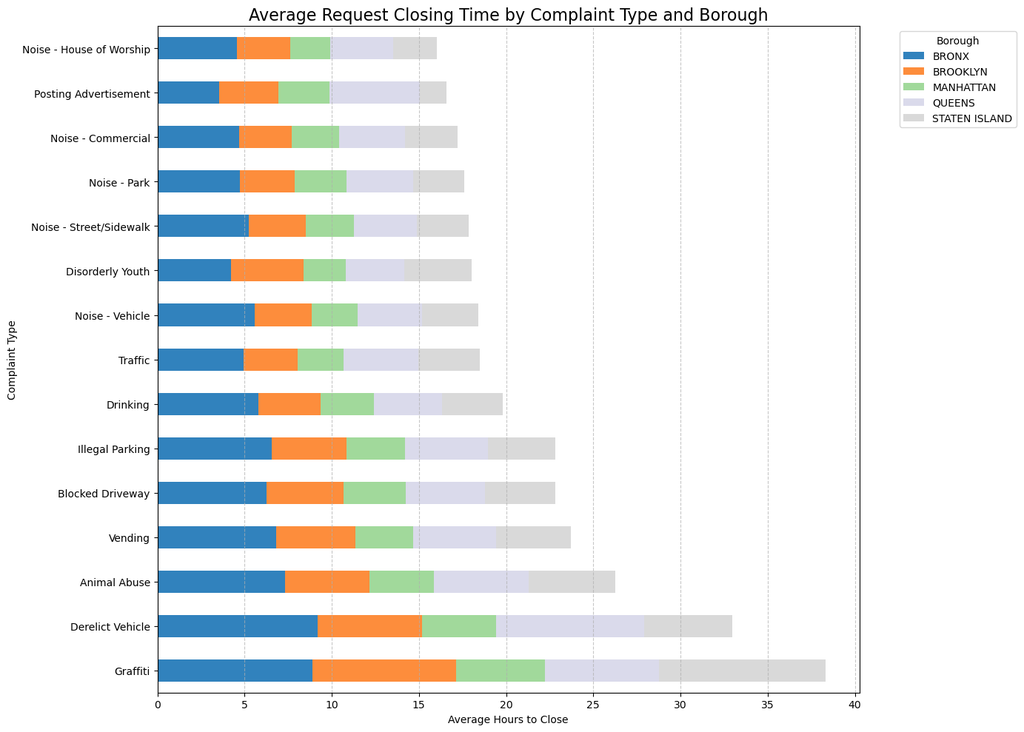

```python
# Grouping by Complaint Type and Borough, compute average closing time
df['Closing_Hours'] = df['Request_Closing_Time'].dt.total_seconds()/3600
avg_closing = df.groupby(['Complaint Type', 'Borough'])['Closing_Hours'].mean().unstack()

# Sorting by overall average across boroughs
avg_closing['Mean'] = avg_closing.mean(axis=1)
avg_closing = avg_closing.sort_values(by='Mean', ascending=False)
avg_closing = avg_closing.drop(columns='Mean')

# Plotting
plt.figure(figsize=(14, 10))
avg_closing.plot(kind='barh', stacked=True, figsize=(14, 10), colormap='tab20c')

plt.title('Average Request Closing Time by Complaint Type and Borough', fontsize=16)
plt.xlabel('Average Hours to Close')
plt.ylabel('Complaint Type')
plt.legend(title='Borough', bbox_to_anchor=(1.05, 1), loc='upper left')
plt.tight_layout()
plt.grid(axis='x', linestyle='--', alpha=0.7)
plt.show()
```

# Statistical Testing

2. Testing 1

```python
import pandas as pd
from scipy.stats import f_oneway

# Assuming your DataFrame is named df

# Group the response times by complaint type
grouped = df.groupby('Complaint Type')['Request_Closing_Time'].apply(list)

# Convert timedelta to hours for better interpretation
grouped_hours = [pd.Series(times).dt.total_seconds() / 3600 for times in grouped]

# Perform one-way ANOVA
f_stat, p_value = f_oneway(*grouped_hours)

# Display results
print(f"F-statistic: {f_stat}")
print(f"P-value: {p_value}")

# Interpretation
if p_value < 0.05:
    print("Reject the Null Hypothesis: Average response time differs across complaint types.")
else:
    print("Fail to Reject the Null Hypothesis: No significant difference in average response time across complaint types.")
```

```
F-statistic: 578.9120337398356
P-value: 0.0
Reject the Null Hypothesis: Average response time differs across complaint types.
```

Testing 2

```python
import pandas as pd
from scipy.stats import chi2_contingency

# Assuming your DataFrame is named df

# Create a contingency table of Complaint Type vs Borough
contingency_table = pd.crosstab(df['Complaint Type'], df['Borough'])

# Perform Chi-Square Test of Independence
chi2_stat, p_value, dof, expected = chi2_contingency(contingency_table)

# Display results
print(f"Chi-Square Statistic: {chi2_stat}")
print(f"P-value: {p_value}")

# Interpretation
if p_value < 0.05:
    print("Reject the Null Hypothesis: Complaint type and location are related.")
else:
    print("Fail to Reject the Null Hypothesis: No significant relationship between complaint type and location.")
```

```
Chi-Square Statistic: 73264.62164334783
P-value: 0.0
Reject the Null Hypothesis: Complaint type and location are related.
```